# Part II - ProsperLoanData

## by Mary Maingi

## Investigation Overview

The main goal is to look at how the loan amount, borrower abr and borrower rate are affected by other variables like Debt to income ratio nd prosper rating.

## Dataset Overview

This data set contains 113,937 loans with 81 variables on each loan, including loan amount, borrower rate (or interest rate), current loan status, borrower income, and many others

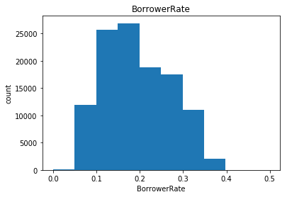

**BorrowerRate**

BorrowerRate has a muiltmodal distribution of values with the highest peak at 0.15

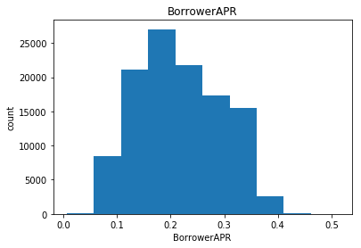

**BorrowerAPR**

BorrowerAPR has a muiltmodal distribution of values with the highest peak at 0.2.

```
Text(0,0.5,'count')
```

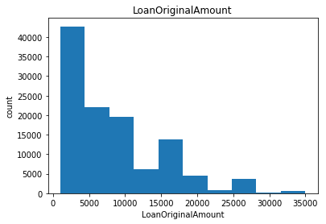

**LoanOriginalAmount**

The loan original mount has the highest bars representing less than 10,000

```
Text(0.5,1,'LoanOriginalAmount versus BorrowerAPR')
```

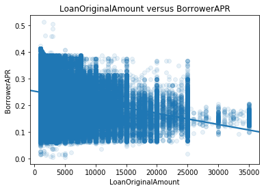

**Relationship between Loan Original Amount and BorrowerAPR**

The borrowerapr is high at some point but decreases as the loan amount increases. This shows that there is a negative correlation between borrowerapr and loan amount

```
Text(0.5,1,'BorrowerRate and DebtToIncomeRatio')
```

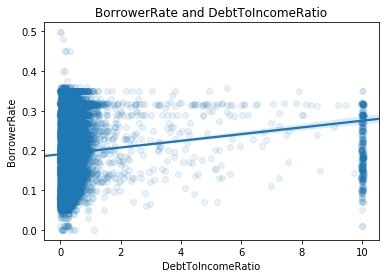

**Relationship between DebtToIncomeRatio and BorrowerRate**

```
Text(0.5,1,'LoanOriginalAmount versus ProsperRating (Alpha)')
```

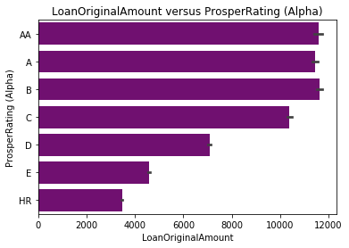

**Relationship between Loan Original Amount and Prosper Rating (Alpha)**

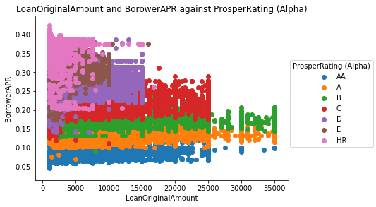

**Effects of Rating on Loan original amount and BorrowerAPR.**

This graph of Loan amount against borrowerapr by prosper rating shows good ratings are seen when there is increase in loan amount and a small increase in borrower apr. The borrower apr increases with ratings from AA, A to B

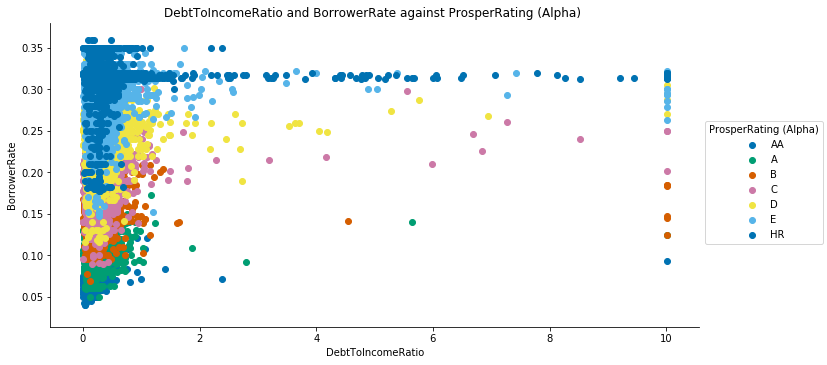

**Effect of prosper rating on debt to income ratio and borrower rate**